# (Generalized) Linear Mixed Models

04 September, 2019

## Linear models

## Linear models

[figure not shown]

How maximize power?

## Linear models

[figure not shown]

How maximize power?

- increase replication
- add covariates (account for conditions)
- **block** (control conditions)

## Hierarchical models

[figure not shown]

How do we increase power - without more sites (replicates)

## Hierarchical models

[figure not shown]

Subreplicates - yet these are not independent

**Nested design**

## Hierarchical models

[figure not shown]

How do we increase power…

## Hierarchical models

[figure not shown]

Block treatments together - yet these are not independent

**Randomized complete design**

## Linear modelling assumptions

- Normality
- Homogeneity of Variance
- Linearity
- **Independence**

[figure not shown]

## Non-independence

- one response is triggered by another
- temporal/spatial autocorrelation
- **nested (hierarchical) design structures**

[figure not shown]

## Hierarchical models

- linear model with separate covariance structure per block
- fixed and random factors (effects)

## Example

```r
#data.rcb <- read.csv('../data/data.rcb.csv')
head(data.rcb)
```

```
##          y        x  block
## 1 281.1091 18.58561 Block1
## 2 295.6535 26.04867 Block1
## 3 328.3234 40.09974 Block1
## 4 360.1672 63.57455 Block1
## 5 276.7050 14.11774 Block1
## 6 348.9709 62.88728 Block1
```

## Example

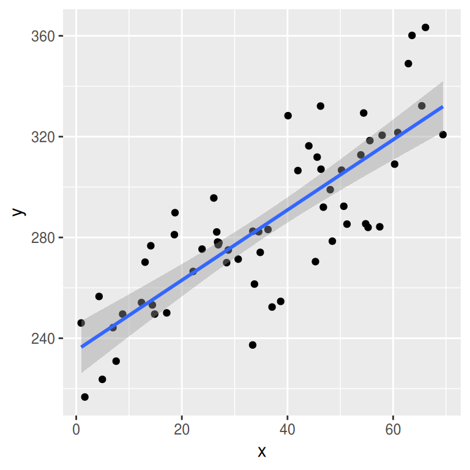

```r
library(ggplot2)
ggplot(data.rcb, aes(y=y, x=x)) + geom_point() + geom_smooth(method='lm')
```

## Example

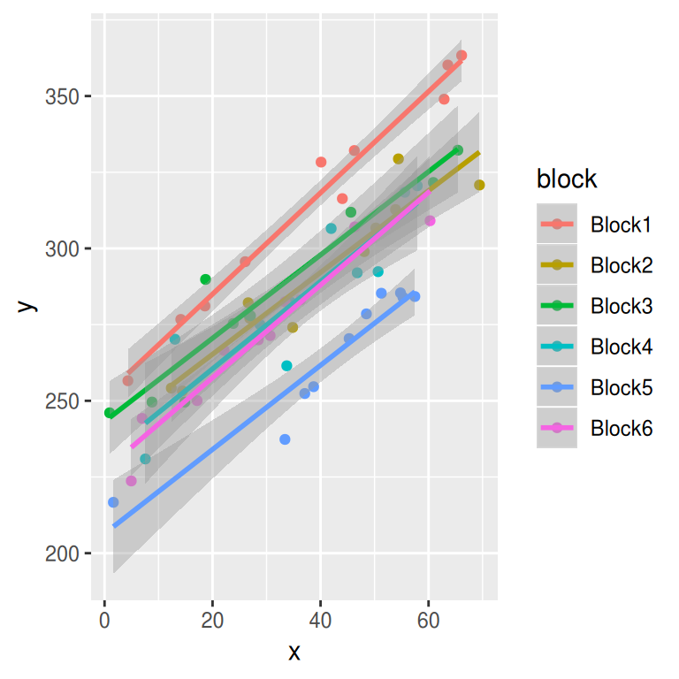

```r
library(ggplot2)
ggplot(data.rcb, aes(y=y, x=x,color=block))+geom_point()+
    geom_smooth(method='lm')
```

## Example

Simple linear regression - wrong

```r
data.rcb.lm <- lm(y~x, data.rcb)
```

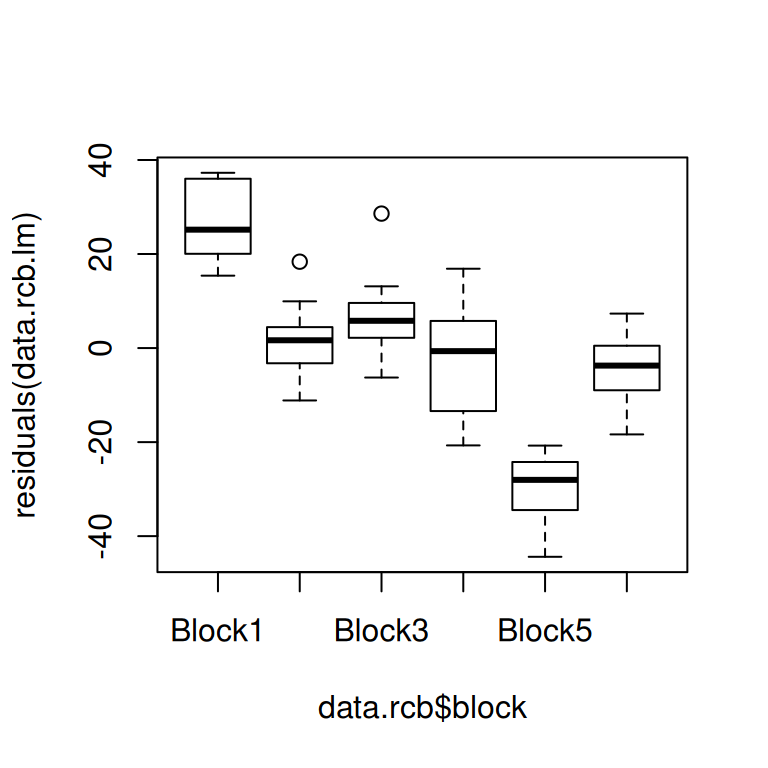

```r
plot(residuals(data.rcb.lm) ~ data.rcb$block)
```

## Example

Simple ANCOVA - wrong

```r
data.rcb.lm1 <- lm(y~x+block, data=data.rcb)
```

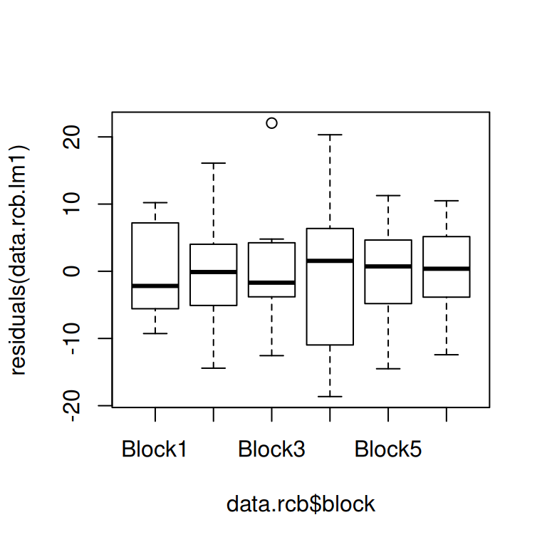

```r
plot(residuals(data.rcb.lm1) ~ data.rcb$block)
```

## Example

- Looks good, but for **INDEPENDENCE**
- Can we deal with that with **correlation structure**?

\[ \text{Variance-covariance per Block:} \mathbf{V} = \begin{pmatrix} \sigma^2&\rho&\cdots&\rho\\ \rho&\sigma^2&\cdots&\vdots\\ \vdots&\cdots&\sigma^2&\vdots\\ \rho&\cdots&\cdots&\sigma^2\\ \end{pmatrix} \]

## Linear mixed effects model

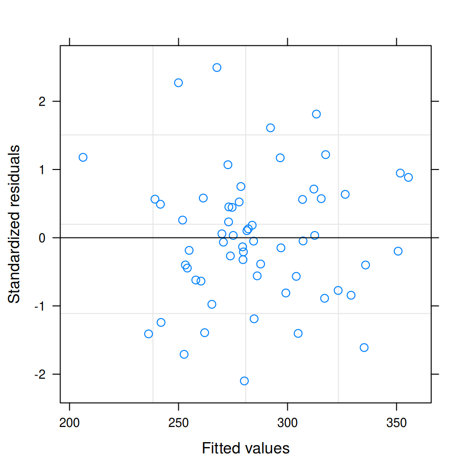

```r
library(nlme)
data.rcb.lme <- lme(y~x, random=~1|block, data.rcb, method='REML')
plot(data.rcb.lme)
```

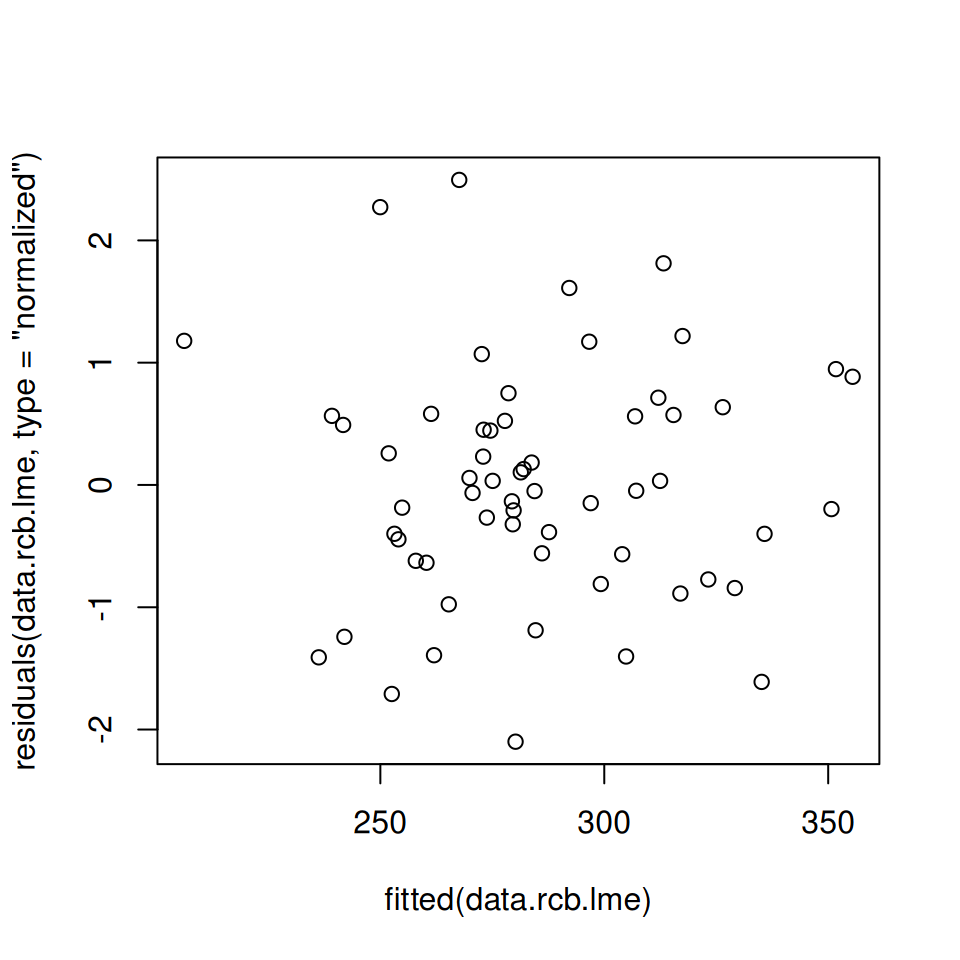

```r
plot(residuals(data.rcb.lme, type='normalized') ~ fitted(data.rcb.lme))
```

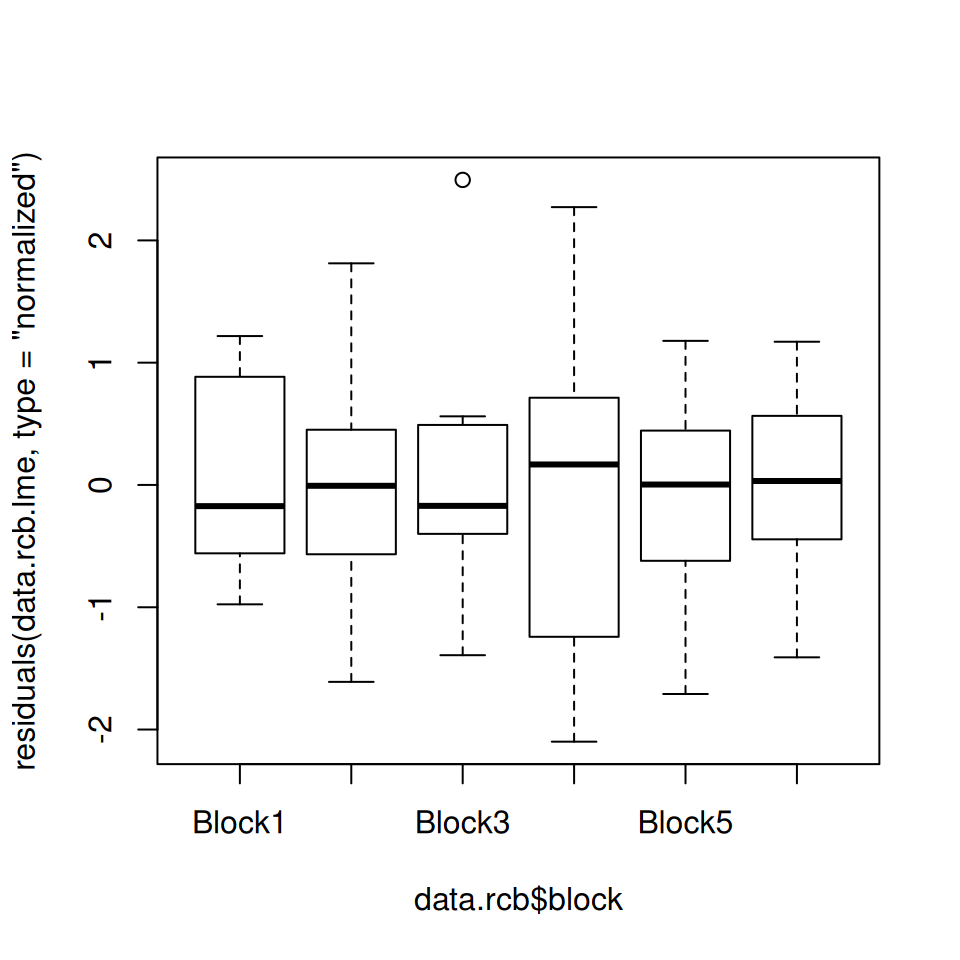

```r
plot(residuals(data.rcb.lme, type='normalized') ~ data.rcb$block)
```

## Linear mixed effects model

```r
summary(data.rcb.lme)
```

```
## Linear mixed-effects model fit by REML
##  Data: data.rcb
##        AIC      BIC   logLik
##   458.9521 467.1938 -225.476
##
## Random effects:
##  Formula: ~1 | block
##         (Intercept) Residual
## StdDev:    18.10888 8.905485
##
## Fixed effects: y ~ x
##                Value Std.Error DF  t-value p-value
## (Intercept) 232.8193  7.823393 53 29.75937       0
## x             1.4591  0.063789 53 22.87392       0
##  Correlation:
##   (Intr)
## x -0.292
##
## Standardized Within-Group Residuals:
##         Min          Q1         Med          Q3         Max
## -2.09947262 -0.57994305 -0.04874031  0.56685096  2.49464217
##
## Number of Observations: 60
## Number of Groups: 6
```

## Linear mixed effects model

```r
anova(data.rcb.lme)
```

```
##             numDF denDF   F-value p-value
## (Intercept)     1    53 1452.2883  <.0001
## x               1    53  523.2164  <.0001
```

```r
intervals(data.rcb.lme)
```

```
## Approximate 95% confidence intervals
##
##  Fixed effects:
##                  lower       est.      upper
## (Intercept) 217.127551 232.819291 248.511031
## x             1.331156   1.459101   1.587045
## attr(,"label")
## [1] "Fixed effects:"
##
##  Random Effects:
##   Level: block
##                    lower     est.    upper
## sd((Intercept)) 9.597555 18.10888 34.16822
##
##  Within-group standard error:
##     lower      est.     upper
##  7.361788  8.905485 10.772879
```

## Linear mixed effects model

```r
vc<-as.numeric(as.matrix(VarCorr(data.rcb.lme))[,1])
vc/sum(vc)
```

```
## [1] 0.8052553 0.1947447
```

## Linear mixed effects model

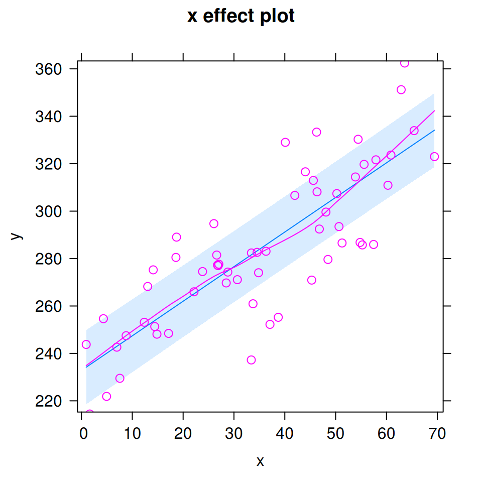

```r
library(effects)
plot(allEffects(data.rcb.lme, partial.residuals=TRUE))
```

## Linear mixed effects model

```r
predict(data.rcb.lme, newdata=data.frame(x=30:40),level=0)
```

```
##  [1] 276.5923 278.0514 279.5105 280.9696 282.4287 283.8878 285.3469
##  [8] 286.8060 288.2651 289.7242 291.1833
## attr(,"label")
## [1] "Predicted values"
```

## Linear mixed effects model

```r
predict(data.rcb.lme, newdata=data.frame(x=30:40,
                          block='Block1'),level=1)
```

```
##   Block1   Block1   Block1   Block1   Block1   Block1   Block1   Block1
## 302.7422 304.2013 305.6604 307.1195 308.5786 310.0377 311.4968 312.9559
##   Block1   Block1   Block1
## 314.4150 315.8741 317.3332
## attr(,"label")
## [1] "Predicted values"
```

## Generalized Linear Mixed Effects Models

## Parameter Estimation

lm –> LME  
(integrate likelihood across all unobserved levels random effects)

## Parameter Estimation

lm –> LME  
(integrate likelihood across all unobserved levels random effects)

glm —-………–> GLMM  
Not so easy - need to approximate

## Parameter Estimation

- Penalized quasi-likelihood
- Laplace approximation
- Gauss-Hermite quadrature

## Penalized quasi-likelihood (PQL)

### Iterative (re)weighting

- LMM to estimate vcov structure
- fixed effects estimated by fitting GLM (incorp vcov)
- refit LMM to re-estimate vcov
- cycle

## Penalized quasi-likelihood (PQL)

### Advantages

- relatively simple
- leverage variance-covariance structures for heterogeneity and dependency structures

### Disadvantages

- biased when expected values less <5
- approximates likelihood (no AIC or LTR)

## Laplace approximation

Second-order Taylor series expansion - to approximate likelihood at unobserved levels of random effects

## Laplace approximation

Second-order Taylor series expansion - to approximate likelihood at unobserved levels of random effects

### Advantages

- more accurate

## Laplace approximation

Second-order Taylor series expansion - to approximate likelihood at unobserved levels of random effects

### Advantages

- more accurate

### Disadvantages

- slower
- no way to incorporate vcov

## Gauss-Hermite quadrature (GHQ)

- approximates value of integrals at specific points (quadratures)
- points (and weights) selected by optimizer

## Gauss-Hermite quadrature (GHQ)

- approximates value of integrals at specific points (quadratures)
- points (and weights) selected by optimizer

### Advantages

- even more accurate

## Gauss-Hermite quadrature (GHQ)

- approximates value of integrals at specific points (quadratures)
- points (and weights) selected by optimizer

### Advantages

- even more accurate

### Disadvantages

- even slower
- no way to incorporate vcov

## Markov Chain Monte Carlo (MCMC)

- recreate likelihood by sampling proportionally to likelihood

## Markov Chain Monte Carlo (MCMC)

- recreate likelihood by sampling proportionally to likelihood

### Advantages

- very accurate (not an approximation)
- very robust

## Markov Chain Monte Carlo (MCMC)

- recreate likelihood by sampling proportionally to likelihood

### Advantages

- very accurate (not an approximation)
- very robust

### Disadvantages

- very slow
- currently complex

## Inference (hypothesis) testing

### GLMM

Depends on:

- Estimation engine (PQL, Laplace, GHQ)
- Overdispersed
- Fixed or random factors

## Inference (hypothesis) testing

| Approximation | Characteristics | Associated inference | R function |
| --- | --- | --- | --- |
| Penalized Quasi-likelihood (PQL) | Fast and simple, accommodates heterogeneity and dependency structures, biased for small samples | Wald tests only | `glmmPQL` (MASS) |
| Laplace | More accurate (less biased), slower, does not accommodates heterogeneity and dependency structures | LRT | `glmer` (lme4), `glmmTMB` (glmmTMB) |
| Gauss-Hermite quadrature | Even more accurate (less biased), even slower, does not accommodates heterogeneity and dependency structures, cant handle more than 1 random effect | LRT | `glmer` (lme4)?? *Does not seem to work* |
| Markov Chain Monte Carlo (MCMC) | Bayesian, very flexible and accurate, yet very slow and complex | Bayesian credibility intervals, Bayesian P-values | Numerous |

## Inference (hypothesis) testing

| Feature | `glmmPQL` (MASS) | `glmer` (lme4) | `glmmTMB` (glmmTMB) | MCMC |
| --- | --- | --- | --- | --- |
| Variance and covariance structures | Yes | - | not yet | Yes |
| Overdispersed (Quasi) families | Yes | - | - | Yes |
| Mixture families | limited | limited | some | Yes |
| Complex nesting | Yes | Yes | Yes | Yes |
| Zero-inflation | - | - | Yes | Yes |
| Resid degrees of freedom | Between-Within | - | - | - |
| Parameter tests | Wald $t$ | Wald $z$ | Wald $z$ | UI |
| Marginal tests (fixed effects) | Wald $F$, $\chi^2$ | Wald $F$, $\chi^2$ | Wald $F$, $\chi^2$ | UI |
| Marginal tests (Random effects) | Wald $F$,$\chi^2$ | LRT | LRT | UI |
| Information criterion | - | AIC | AIC | AIC, WAIC |

## Inference (hypothesis) testing

[figure not shown]

## Additional assumptions

- dispersion
- (multi)collinearity
- design balance and Type III (marginal) SS
- heteroscadacity
- spatial/temporal autocorrelation